# Homework #4: Classification

Hyunsuk Ko

Due: Wed Sept 28 | 11:45am

**DS 6030 | Fall 2022 | University of Virginia**

This is an **independent assignment**. Do not discuss or work with classmates.

# Required R packages and Directories

```r
data.dir = 'https://mdporter.github.io/DS6030/data/' # data directory
library(R6030)     # functions for SYS-6030
library(tidyverse) # functions for data manipulation
library(glmnet)
library(yardstick)
library(dplyr)
```

# Crime Linkage

Crime linkage attempts to determine if two or more unsolved crimes share a common offender. *Pairwise* crime linkage is the more simple task of deciding if two crimes share a common offender; it can be considered a binary classification problem. The linkage training data has 8 evidence variables that measure the similarity between a pair of crimes:

- `spatial` is the spatial distance between the crimes
- `temporal` is the fractional time (in days) between the crimes
- `tod` and `dow` are the differences in time of day and day of week between the crimes
- `LOC`, `POA,` and `MOA` are binary with a 1 corresponding to a match (type of property, point of entry, method of entry)
- `TIMERANGE` is the time between the earliest and latest possible times the crime could have occurred (because the victim was away from the house during the crime).
- The response variable indicates if the crimes are linked ($y=1$) or unlinked ($y=0$).

These problems use the [linkage-train](https://mdporter.github.io/DS6030/data/linkage_train.csv) and [linkage-test](https://mdporter.github.io/DS6030/data/linkage_test.csv) datasets (click on links for data).

```r
train = read.csv('linkage_train.csv')
test = read.csv('linkage_test.csv')

X = glmnet::makeX(
  train = train %>% select(-y),
  test = test
)

X.train = X$x
Y.train = train$y
X.test = X$xtest
```

# Problem 1: Penalized Regression for Crime Linkage

## a. Fit a penalized *linear regression* model to predict linkage. Use a lasso, ridge, or elasticnet penalty (your choice).

- Report the value of $\alpha$ used (if elasticnet)
- Report the value of $\lambda$ used
- Report the estimated coefficients

```r
set.seed(2022)
ridge_cv <- cv.glmnet(X.train, Y.train, alpha = 0, nfolds = 10)
ridge_cv$lambda.min
```

```
#> [1] 0.002327
```

```r
coef(ridge_cv, s = "lambda.min")
```

```
#> 9 x 1 sparse Matrix of class "dgCMatrix"
#>                     s1
#> (Intercept)  9.263e-02
#> spatial     -2.319e-03
#> temporal    -1.548e-04
#> tod         -2.213e-03
#> dow         -5.795e-03
#> LOC          4.263e-02
#> POA          9.321e-03
#> MOA          7.297e-03
#> TIMERANGE    2.499e-05
```

```r
yhat_ridge = predict(ridge_cv, X.test, s = "lambda.min")
```

## b. Fit a penalized *logistic regression* model to predict linkage. Use a lasso, ridge, or elasticnet penalty (your choice).

- Report the value of $\alpha$ used (if elasticnet)
- Report the value of $\lambda$ used
- Report the estimated coefficients

```r
set.seed(2022)
# alpha = 0.5
fit.enet = cv.glmnet(X.train, Y.train, alpha = 0.5, family = "binomial")
fit.enet$lambda.min
```

```
#> [1] 6.912e-05
```

```r
coef(fit.enet, s = "lambda.min")
```

```
#> 9 x 1 sparse Matrix of class "dgCMatrix"
#>                    s1
#> (Intercept) -0.038162
#> spatial     -0.284236
#> temporal    -0.012414
#> tod         -0.113157
#> dow         -0.240099
#> LOC          1.388922
#> POA          0.441772
#> MOA          0.212107
#> TIMERANGE    0.000615
```

```r
yhat_enet = predict(fit.enet, X.test, s = "lambda.min")
```

## c. Produce one plot that has the ROC curves, using the *training data*, for both models (from part a and b). Use color and/or linetype to distinguish between models and include a legend.

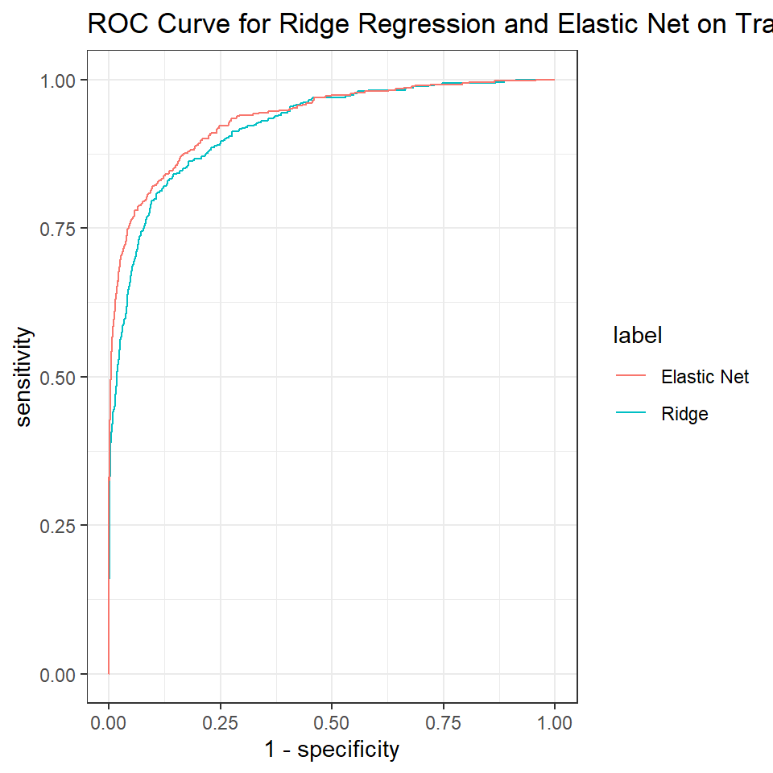

```r
gamma_ridge = predict(ridge_cv, X.train, s = "lambda.min", type = 'link')
gamma_enet = predict(fit.enet, X.train, s = "lambda.min", type = 'link')

ROC_ridge = tibble(truth = factor(Y.train, levels=c(1,0)), gamma = gamma_ridge[,1]) %>%
  yardstick::roc_curve(truth, gamma) %>%
  mutate(label = "Ridge")

ROC_enet = tibble(truth = factor(Y.train, levels=c(1,0)), gamma = gamma_enet[,1]) %>%
  yardstick::roc_curve(truth, gamma) %>%
  mutate(label = "Elastic Net")

ggplot() +
  geom_line(data = ROC_ridge, aes(x = 1-specificity, y = sensitivity, color = label)) +
  geom_line(data = ROC_enet, aes(x = 1-specificity, y = sensitivity, color = label)) +
  labs(title = "ROC Curve for Ridge Regression and Elastic Net on Train Data")
```